# Chapter 2: Descriptive Multivariate Statistics

## Univariate vs. Multivariate Analysis

- **Univariate**: a **single variable**.
- **Multivariate**: **multiple variables**.

## Descriptive Statistics Overview

Descriptive statistics summarize and describe the main features of a dataset. They can be divided into:

1. **Numerical descriptions** – values that capture the center, spread, and shape of the data.
2. **Graphical descriptions** – visualizations that reveal distribution, patterns, and outliers.

## Numerical Description

### Measures of Center

- **Mean** (average)
- **Median** (middle value)
- **Mode** (most frequent value)
- **Trimmed Mean** (mean after removing extremes)

*R code:* mean(x), median(x), ...

### Measures of Spread

These describe how **spread out** the data values are:

- **Variance (var)** – average squared deviation from the mean
- **Standard Deviation (sd)** – square root of the variance
- **Interquartile Range (IQR)** – range of the middle 50% of data
- **Range** – difference between maximum and minimum values

*R code examples:* var(x), sd(x), IQR(x), ...

### Other Measures of Distribution Shape

Beyond center and spread, we often examine **shape**:

- **Skewness** – measures asymmetry of the distribution
  - Positive skew: long right tail
  - Negative skew: long left tail
- **Kurtosis** – measures heaviness of tails compared to a normal distribution
  - High kurtosis: more outliers (heavy tails)
  - Low kurtosis: fewer outliers (light tails)

### Graphical Description

Visualizations provide intuitive insights into the **distribution, variability, and patterns** in data:

- **Histogram** – shows the distribution’s shape and modality
- **Boxplot** – highlights spread, median, and outliers
- **Density Plot** – smooth estimate of distribution
- **Scatterplot** – explores relationships between two variables

## Summary

Descriptive statistics combine **numerical measures** (center, spread, shape) and **graphical tools** (histogram, boxplot, density plot, scatterplot) to give a comprehensive understanding of a dataset.

# 2.1 Linear Transformation

A **linear transformation** from variable $x$ to variable $y$ is given by:

$$ y = a + b x $$

where $a$ and $b$ are constants.

## Effect on Mean and Standard Deviation

- The **mean of $y$** is equal to $a$ plus $b$ times the mean of $x$:
  $$ \mu_y = a + b \mu_x $$
- The **standard deviation of $y$** is equal to the absolute value of $b$ times the standard deviation of $x$:
  $$ \sigma_y = |b| \, \sigma_x $$

## Example: Celsius to Fahrenheit

Temperature conversion formula:

$$ \text{Fahrenheit} = \tfrac{9}{5} \times \text{Celsius} + 32 $$

Suppose we have 20 temperature values in Celsius with:

- Mean = 10°C
- Standard Deviation = 5°C

**Convert to Fahrenheit:**

- The mean in Fahrenheit is:
  $$ \mu_F = \tfrac{9}{5} \times 10 + 32 = 50 $$
- The standard deviation in Fahrenheit is:
  $$ \sigma_F = \tfrac{9}{5} \times 5 = 9 $$

**Result:**  
The mean temperature in Fahrenheit is **50°F**, and the standard deviation is **9°F**.

# 2.2 Graphical Description of Univariate Data

Graphs help us **visualize the distribution of a single variable**. The type of graph depends on whether the data is **quantitative** or **qualitative**.

### Quantitative Data

Used for numerical variables (e.g., height, weight, temperature).

Common plots:

- **Histogram** – shows frequency distribution
- **Density Curve** – smooth estimate of distribution
- **Boxplot** – highlights median, spread, and outliers

### Qualitative Data

Used for categorical variables (in R, these are often stored as **factors**).

Common plots:

- **Bar Chart** – shows counts or proportions for each category
- **Pie Chart** – shows relative proportions in a circle format

```r
# Use the sparrow data.
# Example: Find the mean, variance for varialbe "L_humerous" and construct a histgram for it

#Set the location of the file
lc = "Bumpus_sparrows.csv"

#header = 1  : the variable names are given in the first row of the .csv file
dat= read.csv(lc,  header = 1)

#To check if the data was loaded successfully or not , display the first few line or the last few lines
head(dat)

mean(dat$L_humerous)

dat$Survivorship
```

A data.frame: 6 × 6

|  | Survivorship <chr> | Total_length <int> | Alar_extent <int> | L_beak_head <dbl> | L_humerous <dbl> | L_keel_sternum <dbl> |
| --- | --- | --- | --- | --- | --- | --- |
| 1 | S | 156 | 245 | 31.6 | 18.5 | 20.5 |
| 2 | S | 154 | 240 | 30.4 | 17.9 | 19.6 |
| 3 | S | 153 | 240 | 31.0 | 18.4 | 20.6 |
| 4 | S | 153 | 236 | 30.9 | 17.7 | 20.2 |
| 5 | S | 155 | 243 | 31.5 | 18.6 | 20.3 |
| 6 | S | 163 | 247 | 32.0 | 19.0 | 20.9 |

18.469387755102

1. 'S'

2. 'S'

3. 'S'

4. 'S'

5. 'S'

6. 'S'

7. 'S'

8. 'S'

9. 'S'

10. 'S'

11. 'S'

12. 'S'

13. 'S'

14. 'S'

15. 'S'

16. 'S'

17. 'S'

18. 'S'

19. 'S'

20. 'S'

21. 'S'

22. 'NS'

23. 'NS'

24. 'NS'

25. 'NS'

26. 'NS'

27. 'NS'

28. 'NS'

29. 'NS'

30. 'NS'

31. 'NS'

32. 'NS'

33. 'NS'

34. 'NS'

35. 'NS'

36. 'NS'

37. 'NS'

38. 'NS'

39. 'NS'

40. 'NS'

41. 'NS'

42. 'NS'

43. 'NS'

44. 'NS'

45. 'NS'

46. 'NS'

47. 'NS'

48. 'NS'

49. 'NS'

18.469

0.32

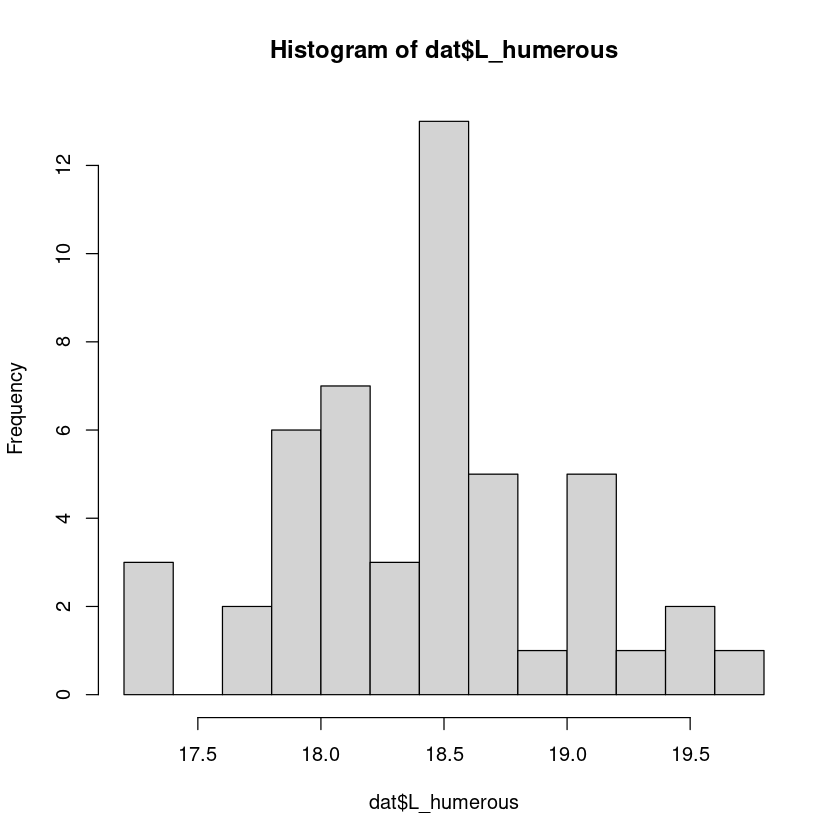

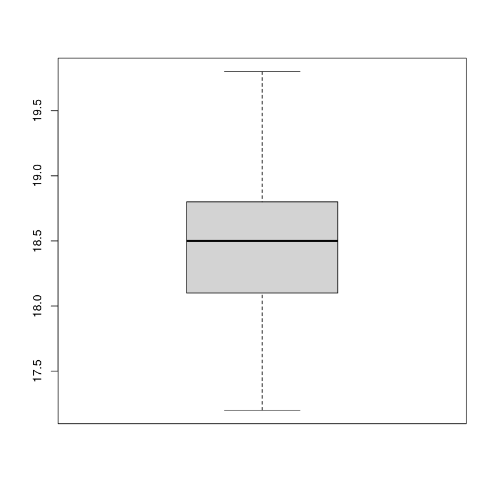

```r
round(mean(dat$L_humerous), 3)

round(var(dat$L_humerous),2)

#Construct a histogram
#breaks : the number of classes of the histogram  roughly
hist(dat$L_humerous, breaks=12)
#Roughly symmetrical

#Symmetrical and unimodal  (approximatly normal) , bell curved
boxplot(dat$L_humerous)
```

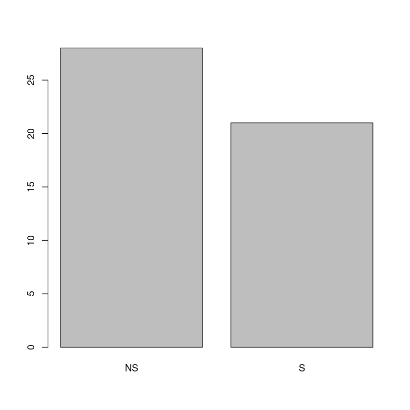

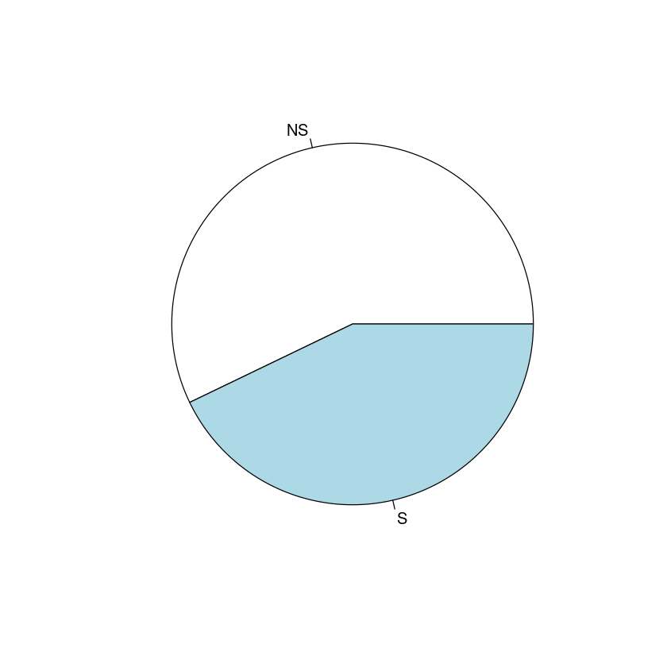

```r
# bar chart for "Survivorship"

#create a frequency table
tabl = table(dat$Survivorship)
barplot(tabl)
pie(tabl)
```

# 2.3 Numerical Description of Multivariate Data

### Measures of Center

For multivariate data with $p$ variables, the measure of center is the **mean vector**:

$$ \bar{\mathbf{x}} = (\bar{x}_1, \bar{x}_2, \cdots, \bar{x}_p)^T $$

### Measures of Spread: Variance and Covariance

- For a **single variable**, variance measures variability.
- For **multiple variables**, the generalization of variance is the **covariance matrix**.
- A **vector** is a one-dimensional array.
- A **matrix** is a two-dimensional array.
- A **tensor** is a multi-dimensional array.

Covariance measures how much **two random variables vary together**.

### Data Matrix

A dataset with $n$ observations (rows) and $m$ variables (columns) can be represented as:

$$ \text{Data Matrix:} \quad \begin{bmatrix} x_{11} & x_{12} & \dots & x_{1m} \\ x_{21} & x_{22} & \dots & x_{2m} \\ \vdots & \vdots & \ddots & \vdots \\ x_{n1} & x_{n2} & \dots & x_{nm} \\ \end{bmatrix} $$

The **mean vector** is:

$$ \bar{X} = \frac{1}{n} \sum_{i=1}^{n} X_i = (\bar{x}_1, \bar{x}_2, \cdots, \bar{x}_m) $$

### Covariance Matrix

where each covariance term is defined as:

$$ s_{ij} = \frac{1}{n-1} \sum_{k=1}^{n} (x_{ki} - \bar{x}_i)(x_{kj} - \bar{x}_j) $$

### Scaling and Normalization

- **Scaling**: Rescale data (e.g., test scores) to a fixed range, such as 0–1.
- **Normalization (Z-score)**:
  $$ z = \frac{\text{data value} - \text{mean}}{\text{standard deviation}} $$

### Correlation Matrix

A **correlation matrix** shows correlation coefficients between variables.  
Correlation is defined as the covariance of **standardized data**.

- Sample correlation coefficient between variables $x$ and $y$:

$$ r_{ij} = \frac{1}{n-1} \sum_{k=1}^{n} \frac{(x_{ki} - \bar{x}_i)(x_{kj} - \bar{x}_j)}{s_i s_j} $$

- The **sample correlation matrix** is:

$$ \Sigma = \begin{bmatrix} 1 & r_{12} & \dots & r_{1m} \\ r_{21} & 1 & \dots & r_{2m} \\ \vdots & \vdots & \ddots & \vdots \\ r_{m1} & r_{m2} & \dots & 1 \\ \end{bmatrix} $$

## Comments on Correlation

- Correlation $r$ always satisfies $-1 \le r \le 1$.
- Extreme values $r = -1$ or $r = 1$ occur when all points lie exactly on a straight line.
- The correlation coefficient $r$ measures only **linear relationships** between two quantitative variables.
- Correlation does **not** capture curved (nonlinear) relationships, even if they are strong.

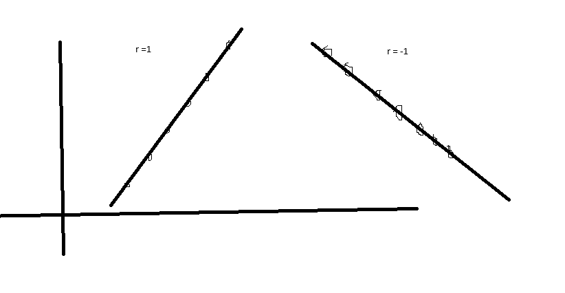

## Interpretation of Correlation

- If there is a **strong positive linear relationship** between two variables, the correlation $r$ is close to **+1**.
- If there is a **strong negative linear relationship**, the correlation $r$ is close to **-1**.
- If two variables have a **weak or no association**, the correlation $r$ is close to **0**.

### Examples

- $r = 0.90$: strong positive linear relationship
- $r = -0.96$: strong negative linear relationship
- $r = 0.30$: weak positive linear relationship
- $r = -0.05$: essentially no linear relationship

## Sensitivity to Outliers

Like the mean and standard deviation, the **linear correlation coefficient** is sensitive to **outliers** and **extreme values**, which can distort the correlation measure.

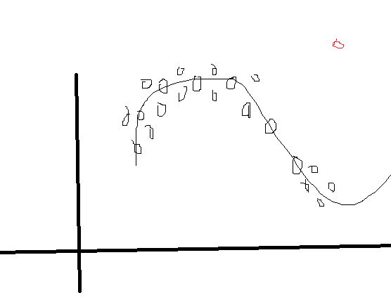

## Important Notes

- The correlation coefficient $r$ measures **only the strength of linear relationships**.
- Correlation does **not** capture nonlinear associations.
- Both the **covariance matrix** and the **correlation matrix** are always **semi–positive definite**.

```r
#Example:  find the mean vector of all quantitative variables
# and calcuate the covariance matrix of these variables.


 dat.qt = dat[, 2:6]
 head(dat.qt)

#The mean vector
 mean.x = colMeans(dat.qt)
 round(mean.x,2)

#The covariance matrix
 cov.mat = round(cov(dat.qt),1)
 cov.mat

#The correlation matrix
 cor1 = cor(dat.qt)
 cor1
```

A data.frame: 6 × 5

|  | Total_length <int> | Alar_extent <int> | L_beak_head <dbl> | L_humerous <dbl> | L_keel_sternum <dbl> |
| --- | --- | --- | --- | --- | --- |
| 1 | 156 | 245 | 31.6 | 18.5 | 20.5 |
| 2 | 154 | 240 | 30.4 | 17.9 | 19.6 |
| 3 | 153 | 240 | 31.0 | 18.4 | 20.6 |
| 4 | 153 | 236 | 30.9 | 17.7 | 20.2 |
| 5 | 155 | 243 | 31.5 | 18.6 | 20.3 |
| 6 | 163 | 247 | 32.0 | 19.0 | 20.9 |

**Total_length**

157.98

**Alar_extent**

241.33

**L_beak_head**

31.46

**L_humerous**

18.47

**L_keel_sternum**

20.83

A matrix: 5 × 5 of type dbl

|  | Total_length | Alar_extent | L_beak_head | L_humerous | L_keel_sternum |
| --- | --- | --- | --- | --- | --- |
| Total_length | 13.4 | 13.6 | 1.9 | 1.3 | 2.2 |
| Alar_extent | 13.6 | 25.7 | 2.7 | 2.2 | 2.7 |
| L_beak_head | 1.9 | 2.7 | 0.6 | 0.3 | 0.4 |
| L_humerous | 1.3 | 2.2 | 0.3 | 0.3 | 0.3 |
| L_keel_sternum | 2.2 | 2.7 | 0.4 | 0.3 | 1.0 |

A matrix: 5 × 5 of type dbl

|  | Total_length | Alar_extent | L_beak_head | L_humerous | L_keel_sternum |
| --- | --- | --- | --- | --- | --- |
| Total_length | 1.0000000 | 0.7349642 | 0.6618119 | 0.6452841 | 0.6051247 |
| Alar_extent | 0.7349642 | 1.0000000 | 0.6737411 | 0.7685087 | 0.5290138 |
| L_beak_head | 0.6618119 | 0.6737411 | 1.0000000 | 0.7631899 | 0.5262701 |
| L_humerous | 0.6452841 | 0.7685087 | 0.7631899 | 1.0000000 | 0.6066493 |
| L_keel_sternum | 0.6051247 | 0.5290138 | 0.5262701 | 0.6066493 | 1.0000000 |

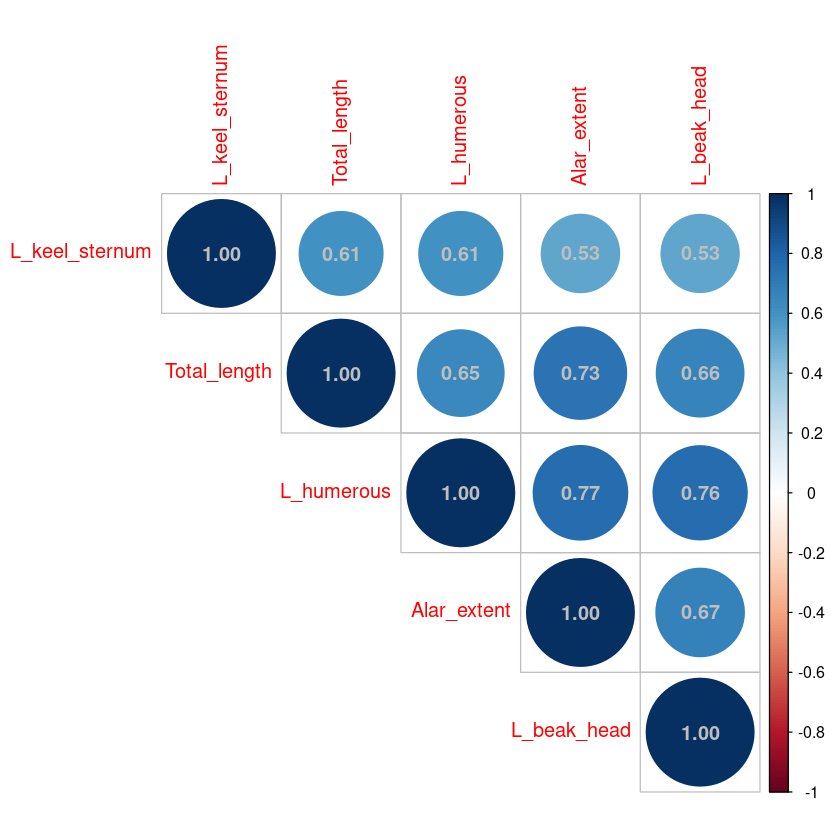

```r
# To visulize the covaraince and correlation matrix
# heatmap
# correlation plot
#cor.mat = cor(dat0)

#Using graphs to visulize the correlation matrix

#Package "corrplot" is needed
#install.packages("corrplot")
library(corrplot)
corrplot(cor1, type="upper", order = 'AOE', addCoef.col = 'grey')

#heatmap(cor1)
```

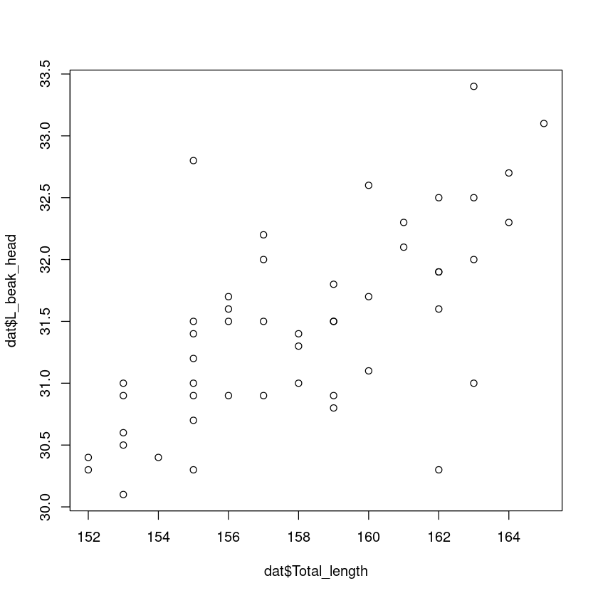

```r
# Data visulization of multivariate data
# scatter plot matrix
# A scatter plot is to show the relationship between two quantitaive variables
# a scatter plot "total length " against "L_beak_head"
plot(dat$Total_length, dat$L_beak_head)

#There is a linear relationship, with one outlier.
```

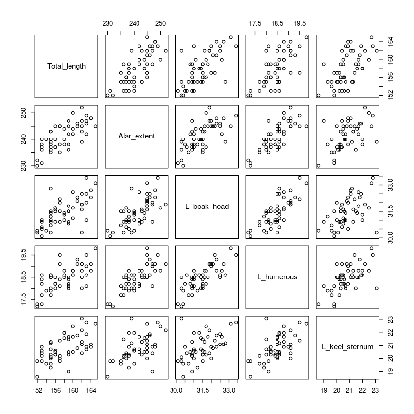

```r
# Data visulization of multivariate data
# scatter plot matrix
# A scatter plot is to show the relationship between two quantitaive variables

#All scatter plots for all pairs of quantitative variables
pairs(dat.qt)
```

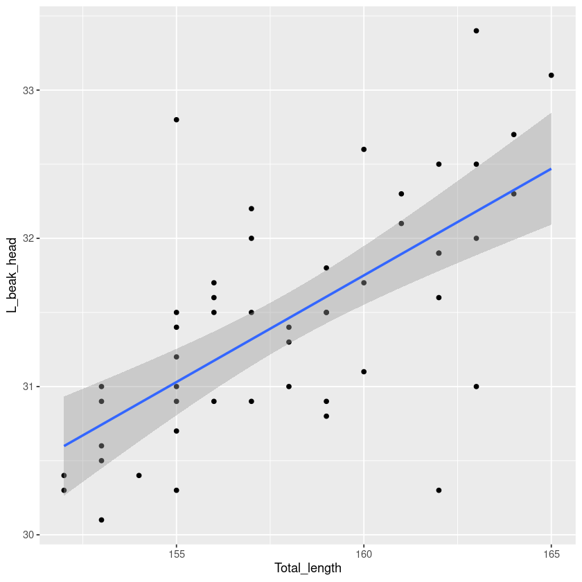

```r
#Scatter plot for two quantitative variables L_beak_head and Alar_extent
#Point plots:   geom_point()
# adding a smoothing line:   geom_smooth(method = "loess")

#To see the relationship between two quantitative variables
library(ggplot2)
p1 = ggplot(data= dat.qt, aes(x = Total_length, y=L_beak_head))+ geom_point()  +
     geom_smooth(method = "lm") + labs(y= "L_beak_head", x = "Total_length")

p1
```

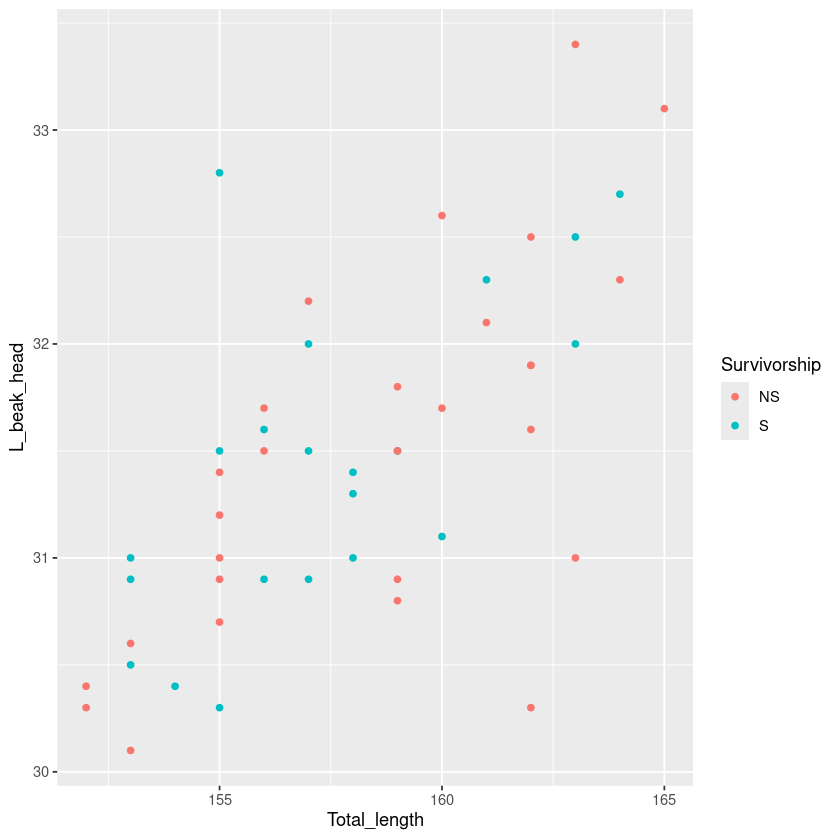

```r
#To see how "L_beak_head" affects "Alar_extent" for different status of "Survivorship"
#Add "Survivorship" into the scatterplot using differnet color or symbol

p3 = ggplot(data= dat, aes(x = Total_length, y=L_beak_head, color = Survivorship ))+ geom_point() +
     labs(y= "L_beak_head", x = "Total_length")

p3


#p2 = ggplot(data= dat, aes(x = L_beak_head , y = Alar_extent, color = Survivorship ))+ geom_point()  +
#     geom_smooth(method = "lm")  + labs(y= "Alar_extent", x = "L_beak_head")
#p2
```

```r
#Summerize the mean of each

# summarize  Alar_extent , and L_beak_head , by their means for each Survivorship group
# group_by()

library(tidyverse)
#pipe operation %>%

dat %>% group_by(Survivorship) %>% summarize( mean.Alar_extent=mean(Alar_extent), mean.L_beak_head = mean(L_beak_head), sd.2=sd(Alar_extent))
```

A tibble: 2 × 4

| Survivorship <chr> | mean.Alar_extent <dbl> | mean.L_beak_head <dbl> | sd.2 <dbl> |
| --- | --- | --- | --- |
| NS | 241.5714 | 31.47857 | 5.705284 |
| S | 241.0000 | 31.43333 | 4.183300 |

# Graphical tools for multivariate data

1. Chernoff faces:

Chernoff faces is to present multivariate variables simultaneously by mapping elements of the human face, such as ears, hair, eyes, and nose, according to numerical values in a dataset. The underlying idea is that since we are adept at interpreting facial expressions in everyday life, we should likewise be capable of discerning subtle variations when they correspond to data points.

Package aplpack

2. Star plots

Star plots (Chambers, et al., 1983, pp. 158-162) are a useful way to display multivariate observations with an arbitrary number of variables. Each observation is represented as a star-shaped figure with one ray for each variable. For a given observation, the length of each ray is made proportional to the size of that variable. Star plots differ from glyph plots in that all variables are used to construct the plotted star figure; there is no separation into foreground and background variables.

3. Profile plots or Parallel Coordinate Plots

```
effect of variables:
 modified item       Var
 "height of face   " "Total_length"
 "width of face    " "Alar_extent"
 "structure of face" "L_beak_head"
 "height of mouth  " "L_humerous"
 "width of mouth   " "L_keel_sternum"
 "smiling          " "Total_length"
 "height of eyes   " "Alar_extent"
 "width of eyes    " "L_beak_head"
 "height of hair   " "L_humerous"
 "width of hair   "  "L_keel_sternum"
 "style of hair   "  "Total_length"
 "height of nose  "  "Alar_extent"
 "width of nose   "  "L_beak_head"
 "width of ear    "  "L_humerous"
 "height of ear   "  "L_keel_sternum"
```

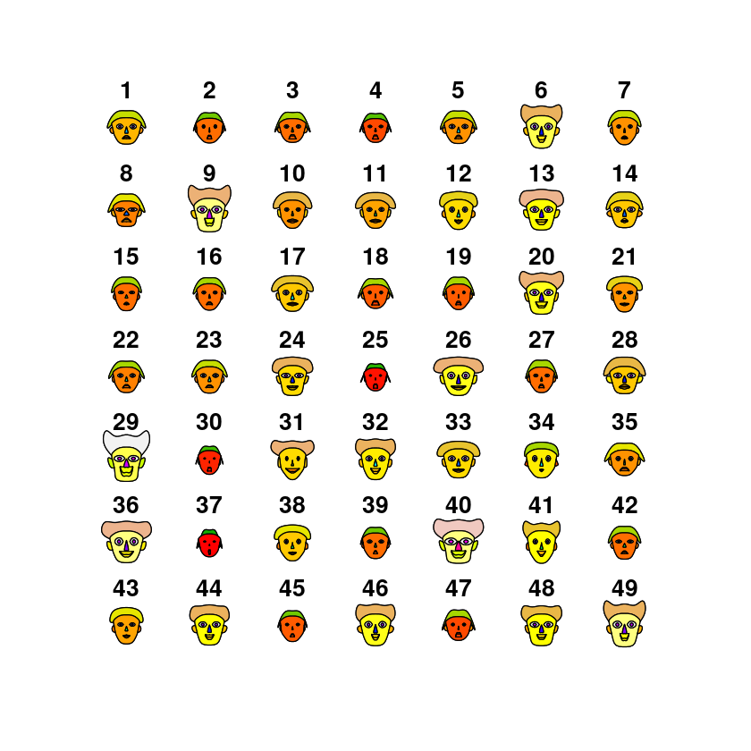

```
effect of variables:
 modified item       Var
 "height of face   " "Total_length"
 "width of face    " "Alar_extent"
 "structure of face" "L_beak_head"
 "height of mouth  " "L_humerous"
 "width of mouth   " "L_keel_sternum"
 "smiling          " "Total_length"
 "height of eyes   " "Alar_extent"
 "width of eyes    " "L_beak_head"
 "height of hair   " "L_humerous"
 "width of hair   "  "L_keel_sternum"
 "style of hair   "  "Total_length"
 "height of nose  "  "Alar_extent"
 "width of nose   "  "L_beak_head"
 "width of ear    "  "L_humerous"
 "height of ear   "  "L_keel_sternum"
```

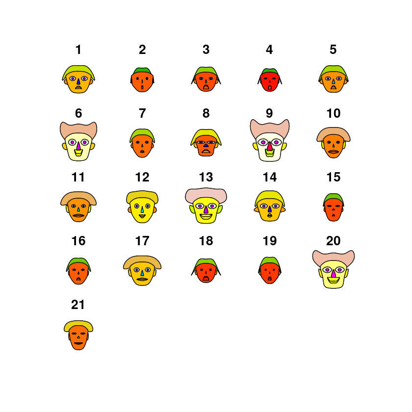

```
effect of variables:
 modified item       Var
 "height of face   " "Total_length"
 "width of face    " "Alar_extent"
 "structure of face" "L_beak_head"
 "height of mouth  " "L_humerous"
 "width of mouth   " "L_keel_sternum"
 "smiling          " "Total_length"
 "height of eyes   " "Alar_extent"
 "width of eyes    " "L_beak_head"
 "height of hair   " "L_humerous"
 "width of hair   "  "L_keel_sternum"
 "style of hair   "  "Total_length"
 "height of nose  "  "Alar_extent"
 "width of nose   "  "L_beak_head"
 "width of ear    "  "L_humerous"
 "height of ear   "  "L_keel_sternum"
```

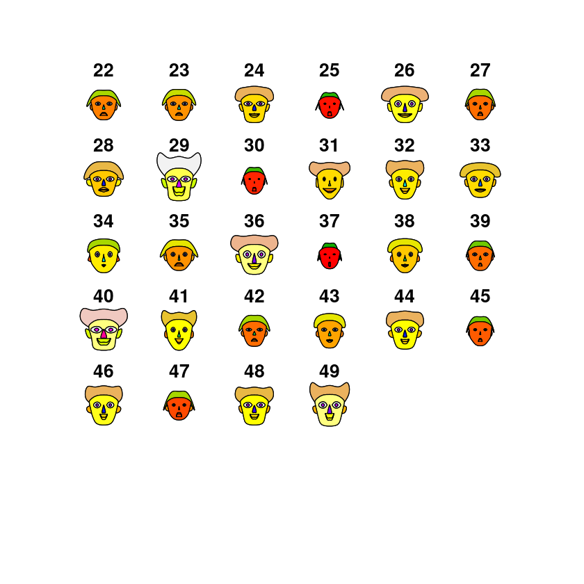

```r
#Chernoff faces
library(aplpack)
#This is only for data with quantitative variables
faces(dat.qt)

#A sub set with all survived birds
index = dat$Survivorship=="S"
dat.qt1 = dat[index, 2:6]

#A sub set with all non-survived birds
dat.qt2 = dat[!index, 2:6 ]

#Face plots for different Survivorship
faces(dat.qt1)
faces(dat.qt2)
```

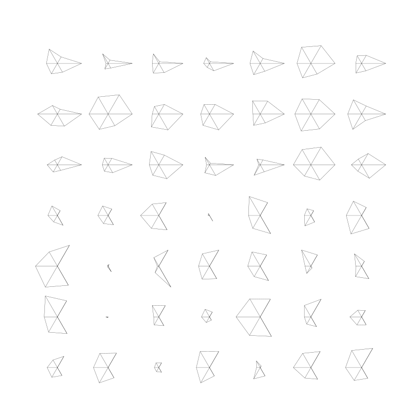

```r
#Construct a star plot for the Bird data
stars(dat)
#stars(dat, len = 0.8, key.loc = c(12, 2), main = "Bird data", draw.segments = TRUE)
```

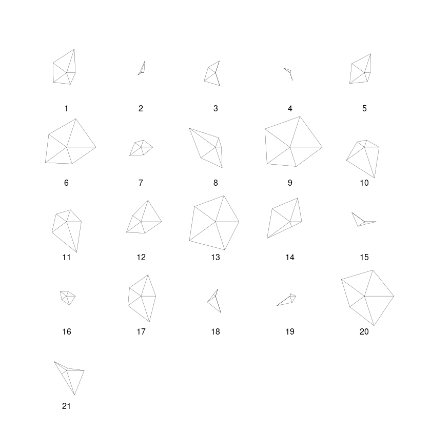

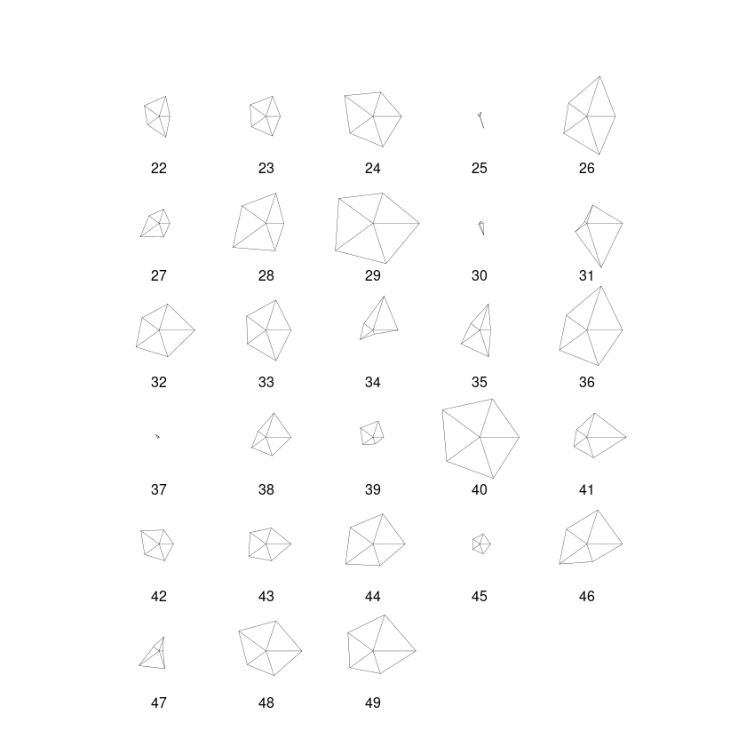

```r
stars(dat.qt1)
stars(dat.qt2)
```

# Profile plots or Parallel Coordinate Plots

A parallel coordinate plot illustrates each row in a dataset as a line or profile, with each feature of a row represented by a point on the line. Although parallel coordinate plots may resemble line charts, their approach to translating data into a plot differs significantly. This visualization technique is well-suited for representing multivariate, quantitative data, making it ideal for comparing numerous variables and discerning the relationships among them.

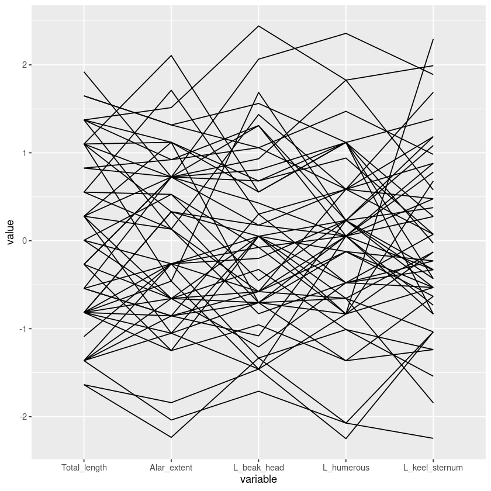

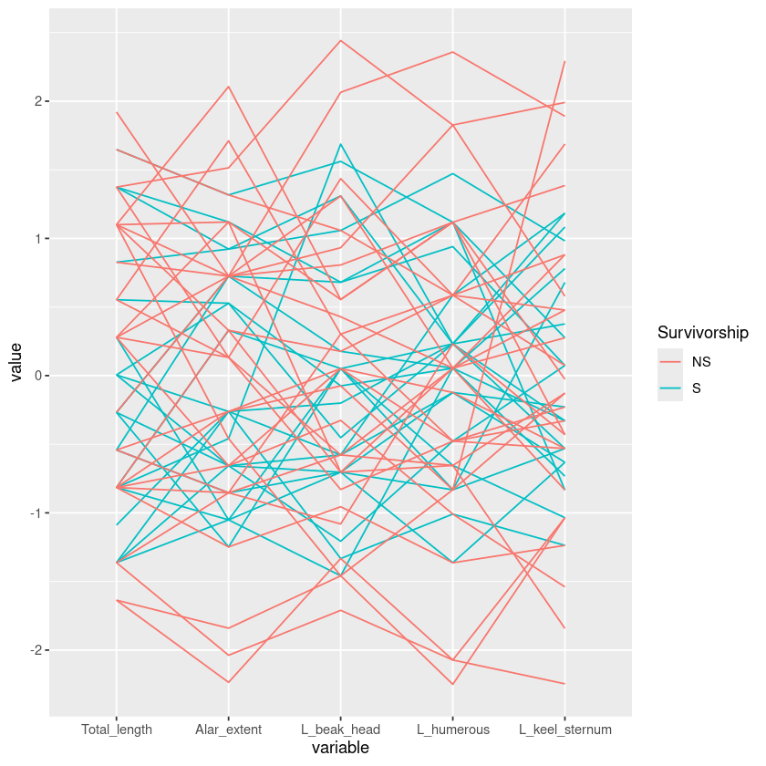

```r
library(GGally)

#dat.qt = dat[, 2:6]
ggparcoord(dat.qt)

#The survivorship is in the first column
ggparcoord(dat , columns = c(2:6), groupColumn=1)

#str(dat.qt)

#It seems that median size birds are more likely to survive.
```

Interpretation: say something that you see about the data from the plots.

Maybe: the features of survived cases are less variant. ....

```
            There are no patterns at all.
```

...

A tibble: 2 × 6

| Survivorship <chr> | m1 <dbl> | m2 <dbl> | m3 <dbl> | m4 <dbl> | m5 <dbl> |
| --- | --- | --- | --- | --- | --- |
| NS | 158.4286 | 241.5714 | 31.47857 | 18.44643 | 20.83929 |
| S | 157.3810 | 241.0000 | 31.43333 | 18.50000 | 20.80952 |

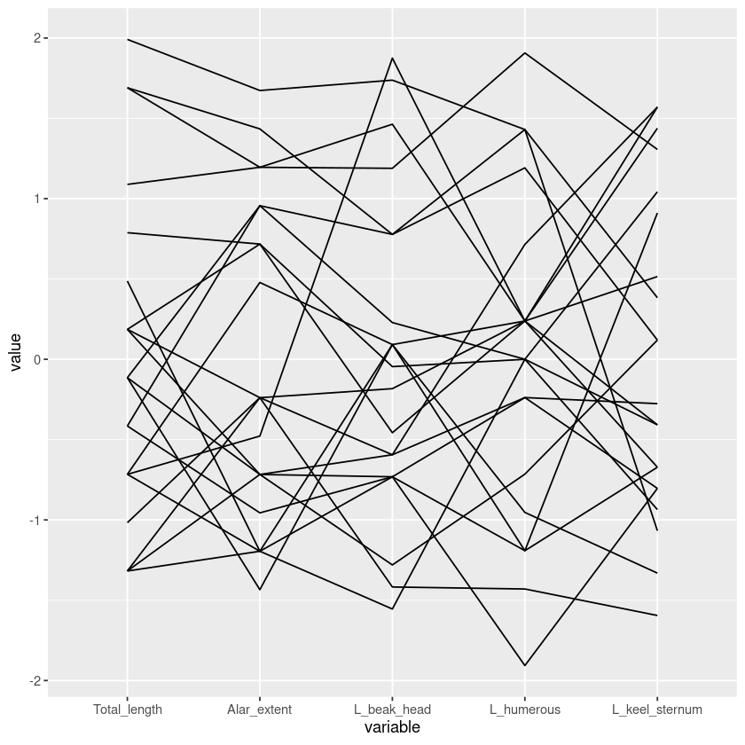

```
effect of variables:
 modified item       Var
 "height of face   " "m1"
 "width of face    " "m2"
 "structure of face" "m3"
 "height of mouth  " "m4"
 "width of mouth   " "m5"
 "smiling          " "m1"
 "height of eyes   " "m2"
 "width of eyes    " "m3"
 "height of hair   " "m4"
 "width of hair   "  "m5"
 "style of hair   "  "m1"
 "height of nose  "  "m2"
 "width of nose   "  "m3"
 "width of ear    "  "m4"
 "height of ear   "  "m5"
```

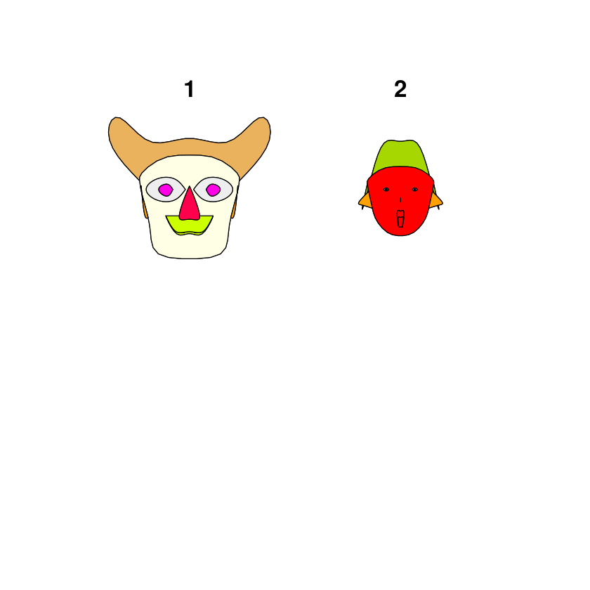

[figure not shown]

```r
#Plot for each group

ggparcoord(dat.qt[dat$Survivorship=="S", ])

#aggregate for each group
#Find the mean vector of Survivorship=="S" cases
#Find the mean vector of Survivorship=="NS" cases

library(tidyverse)
mean.grp = dat %>% group_by(Survivorship) %>% summarize(m1= mean(Total_length),
                                                      m2= mean(Alar_extent), m3= mean(L_beak_head), m4= mean(L_humerous), m5=mean(L_keel_sternum))

mean.grp

faces(mean.grp[,2:6])
#They look different.
#stars(mean.grp[,2:6])
```

# Multivariate skewness and kurtosis

The univariate version:

The variance of a random variable: $$E(X - EX)^2$$

The sample variance $$ s^2 = \frac{1}{n-1} \sum (x_i - \bar {x} )^2$$

Skewness is related to 3 rd momement of a random variable population skewness is related to $$EX^3$$.

The sample skewness: $$\frac{1}{n} \sum (x_i - \bar {x} )^3/s^3$$

kurtosis is related to 4th moment of a random variable

The sample kurtosis (different versions exist): $$\frac{1}{n} \sum (x_i - \bar {x} )^4/s^4 - 3 $$

The skewness is around zero, if a distribution is symmetric about the mean. a positive skewness indicates that the distribution is skewed to the right.  
A negative skewness indicates that the distribution is skewed to the left.

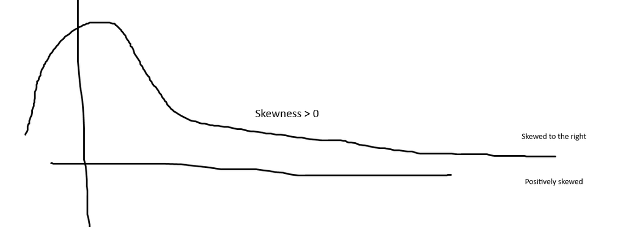

Kurtosis measures how peaked the distribution is. The kurtosis of a normal distribution is 0. Kurtosis characterizes the relative peakedness or flatness of a distribution compared to the normal distribution. If kurtosis is above zero, the tail of the distribution is longer than a normal distribution. If kurtosis is belwo zero, the tail of the distribution is shorter than a normal distribution.

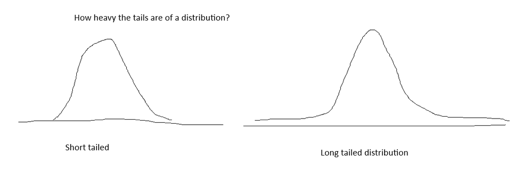

The multivariate version:

Population Multivariate skewness and Kurtosis:

$$ \beta_{1,p} = E[(\mathbf{x}- \mathbf{\mu})^T \mathbf{\Sigma}^{-1} (\mathbf{x} - \mathbf{\mu})]^3 $$

$$ \beta_{2,p} = E[(\mathbf{x}- \mathbf{\mu})^T \mathbf{\Sigma}^{-1} (\mathbf{x} - \mathbf{\mu})]^2 $$

The sample skewness and kurtosis:

For a sample of size n, $$ \hat{\beta}_{1,p} = \frac{1}{n^2}\sum_{i=1}^n \sum_{j=1}^n \left [(\mathbf{x}_i - \bar{\mathbf{x}})^T \mathbf{S}^{-1} (\mathbf{x}_j - \bar{\mathbf{x}}) \right ]^{3} $$

$$ \hat{\beta}_{2,p} = \frac{1}{n} \sum_{i=1}^n \left [(\mathbf{x}_i - \bar{\mathbf{x}})^T \mathbf{S}^{-1} (\mathbf{x}_i - \bar{\mathbf{x}}) \right ]^2 $$

In different statistical packages, they may use different formula for calcualtion. The results may be slightly different. Multivariate skewness and kurtosis measure the same shape characteristics as in the univariate case. However, instead of making the comparison of the distribution of one variable against a univariate normal distribution, they are comparing the joint distribution of several variables against a multivariate normal distribution.

1. Calculation
2. The information from the results

```r
#Univariate skewness for all 5 quantitative variables

library(psych)
#Example 1: find the skewness of "Total_length"

x = dat$Total_length
skew(x, na.rm=TRUE, type = 3 )

#To calculate the skewness of all quantitative variables
#apply function :  apply a function to all column or rows
#dat[,2:6]


#The skewness of "Total_length" is 0.143.

#To calculate the skewness of all quantitative variables
# for each column :  2
# for each row :  1
round(apply(dat[,2:6], 2, skew ), 2)
#skew(dat[,-1])

library(knitr)

# Apply skewness function across variables 9-50
skew_vals = apply(dat[, 2:6], 2, skew)

# Round and convert to data frame
skew.dat = data.frame(
  Variable = names(skew_vals),
  Skewness = round(skew_vals, 2),
  row.names = NULL
)

kable(skew.dat, align = "lc", caption = "Skewness of all Quantitative Variables")
```

0.143967987614435

**Total_length**

0.14

**Alar_extent**

-0.13

**L_beak_head**

0.37

**L_humerous**

-0.05

**L_keel_sternum**

0.23

```
Table: Skewness of all Quantitative Variables

|Variable       | Skewness |
|:--------------|:--------:|
|Total_length   |   0.14   |
|Alar_extent    |  -0.13   |
|L_beak_head    |   0.37   |
|L_humerous     |  -0.05   |
|L_keel_sternum |   0.23   |
```

```r
#Find the kurtosis for L_beak_head
x = dat$L_beak_head
describe(x)
```

A psych: 1 × 13

|  | vars <dbl> | n <dbl> | mean <dbl> | sd <dbl> | median <dbl> | trimmed <dbl> | mad <dbl> | min <dbl> | max <dbl> | range <dbl> | skew <dbl> | kurtosis <dbl> | se <dbl> |
| --- | --- | --- | --- | --- | --- | --- | --- | --- | --- | --- | --- | --- | --- |
| X1 | 1 | 49 | 31.45918 | 0.7947532 | 31.5 | 31.42683 | 0.88956 | 30.1 | 33.4 | 3.3 | 0.3690515 | -0.6078152 | 0.1135362 |

```r
#Multivariate skewness and kurtosis
#psych
mardia(dat[,2:6], na.rm = TRUE, plot=FALSE)

#The multivariate skewness for all quantative variables is 39.46
#The multivariate kurtosis =  -0.22
```

```
Call: mardia(x = dat[, 2:6], na.rm = TRUE, plot = FALSE)

Mardia tests of multivariate skew and kurtosis
Use describe(x) the to get univariate tests
n.obs = 49   num.vars =  5
b1p =  4.83   skew =  39.46  with probability  <=  0.28
 small sample skew =  42.73  with probability <=  0.17
b2p =  34.48   kurtosis =  -0.22  with probability <=  0.83
```